# Positron

### Stopping Applications

We can stop the application like we would any other Terminal process:

`Ctrl` + `C`

After stopping the application, you can clear the Viewer by clicking on the Clear the current URL icon in the upper-right corner.

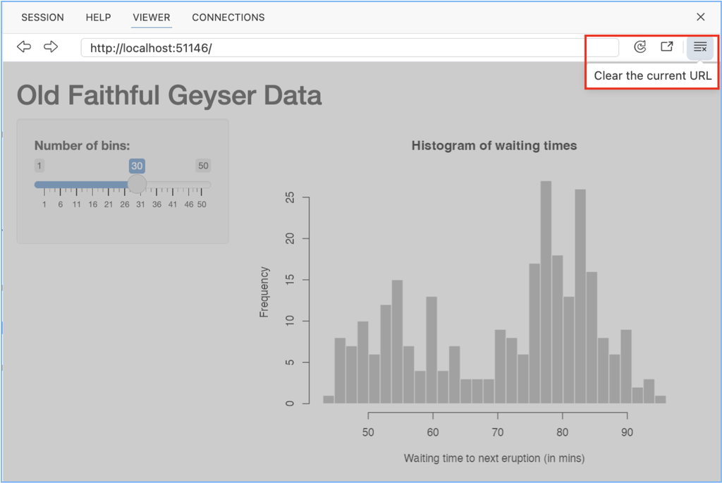

Clear viewer (click to enlarge)

These changes make application development much more seamless, and now the `app.R` file also includes icon for editing our Shiny UI with the [`shinyuieditor` package](https://rstudio.github.io/shinyuieditor/) (provided it’s installed).

[figure not shown]

Run Shiny App Options

## Package Development

Transitioning from developing R packages in RStudio to Positron has been pretty smooth. For example, I wanted to change the [`display_type()`](https://mjfrigaard.github.io/shiny-app-pkgs/launch.html#shiny.launch.browser) function to check if the application runs in RStudio before setting the `shiny.launch.browser` option.[^12]

**TipPositron tab-completion**

Positron also comes with IntelliSense for R functions. Place your cursor inside the parentheses and use `^`+`SPACE` or `tab`:

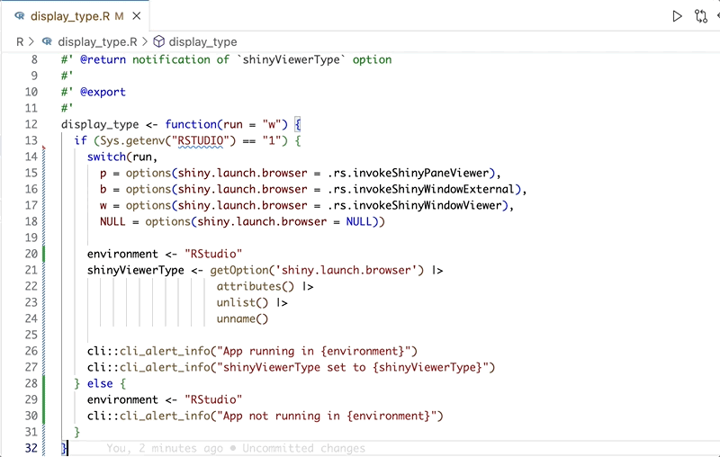

Positron function IntelliSense

### Loading & Documenting

After making changes to `R/display_type.R`, I can use the same keyboard shortcuts from `devtools` to load and document the package:

`Cmd` / `Ctrl` + `Shift` + `L` = `devtools::load_all()`

`Cmd` / `Ctrl` + `Shift` + `D` = `devtools::document()`

Under the hood, Positron calls [`devtools::load_all()`](https://r-pkgs.org/code.html#sec-code-load-all) and [`devtools::document()`](https://r-pkgs.org/man.html), but instead of launching a **Build** pane, Positron displays the messages from in the Console:

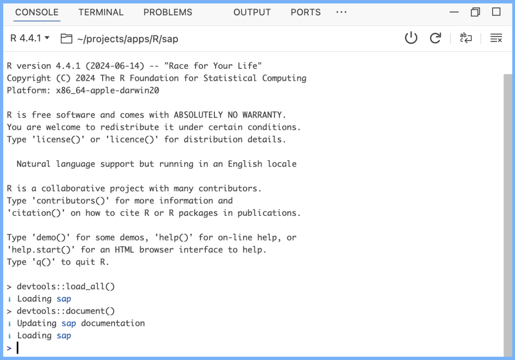

Document R/display_type.R (click to enlarge)

The display_type.Rd in the Console is a hyperlink we can use to preview our updated help file.

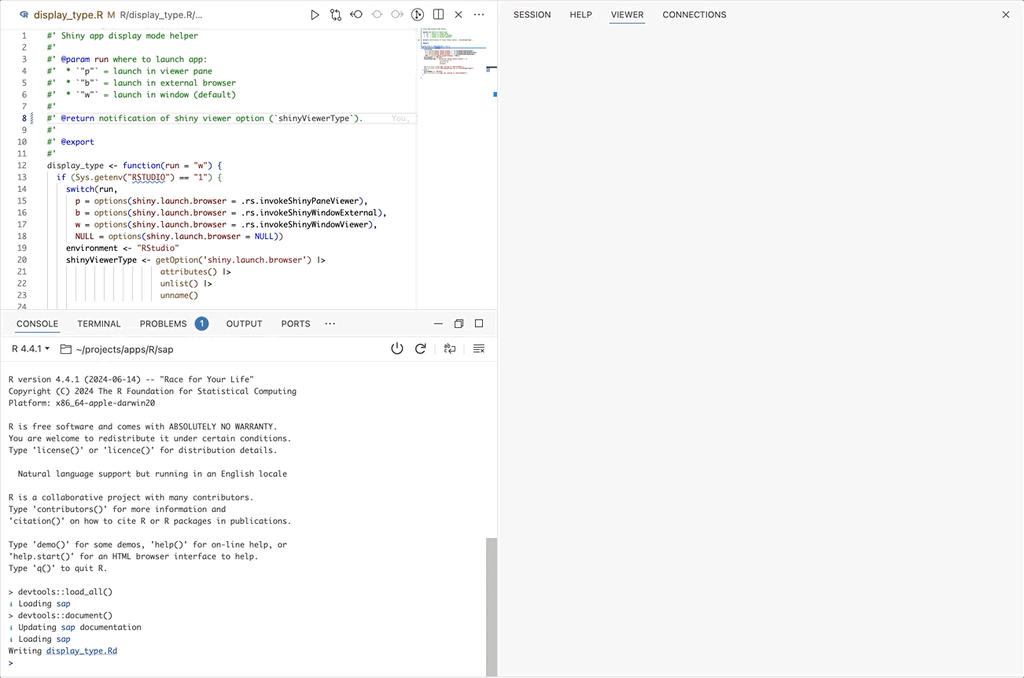

Preview help file for R/display_type.R (click to enlarge)

### Installing

Positron uses the same keyboard shortcut as RStudio for installing packages, but the underlying process differs slightly. Instead of calling [`devtools::install()`](https://devtools.r-lib.org/reference/install.html) in the *Build* pane, Positron launches the Terminal and runs `pak::local_install(upgrade = FALSE)`:

`Cmd` / `Ctrl` + `Shift` + `B` = `pak::local_install(upgrade = FALSE)`

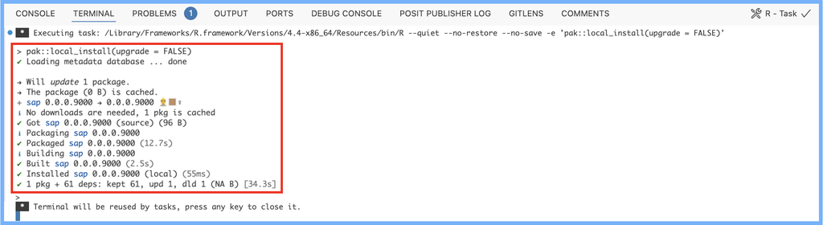

The new package install Terminal commands are bookended with an asterick (`*`) and a message (click to enlarge)

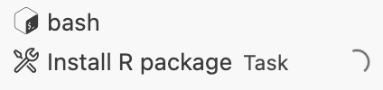

The Terminal pane displays a dedicated Install R package task when a package is installed.

[`local_install(upgrade = FALSE)`](https://pak.r-lib.org/reference/local_install.html) updates the package with the minimum work needed, upgrading dependencies only if the package or one of its dependencies requires a higher version. It prefers binary packages to source packages, even if the binaries are older.

`local_install()` also seems to takes a bit longer to run than `devtools::install()`, but the end result is the same (i.e., the package is installed, the R session restarts, and the package is loaded with `library()` in the Console).

**TipIntelliSense**

In the Console, Positron’s tab completion and IntelliSense displays a large preview each function’s help file:

[figure not shown]

Preview of help file with IntelliSense

### Testing

Positron comes with a variety of options for testing code. We can use the standard keyboard shortcut to call `devtools::test()`. This will open a Terminal task with the test results:[^13]

`Cmd` / `Ctrl` + `Shift` + `T` = `devtools::test()`

[figure not shown]

Running `devtools::test()` (click to enlarge)

[figure not shown]

Positron also has a dedicated testing sidebar menu item that allows us to select or filter the test files in the `tests/testthat/` folder.

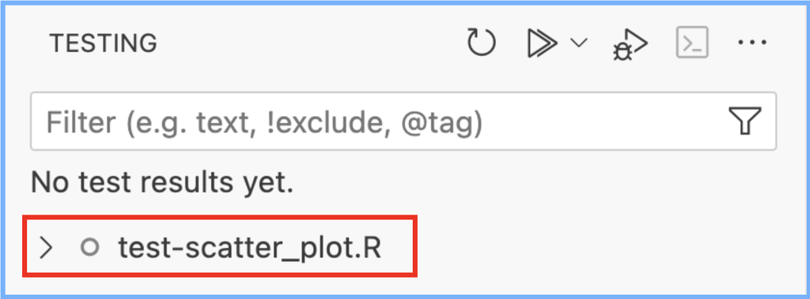

Test files in `tests/testthat/` (click to enlarge)

The testing sidebar menu also displays the contents of each test file. If you’re using `testthat`’s behavior-driven development functions (`describe` and `it`), the descriptions are organized hierarchically under TESTING:

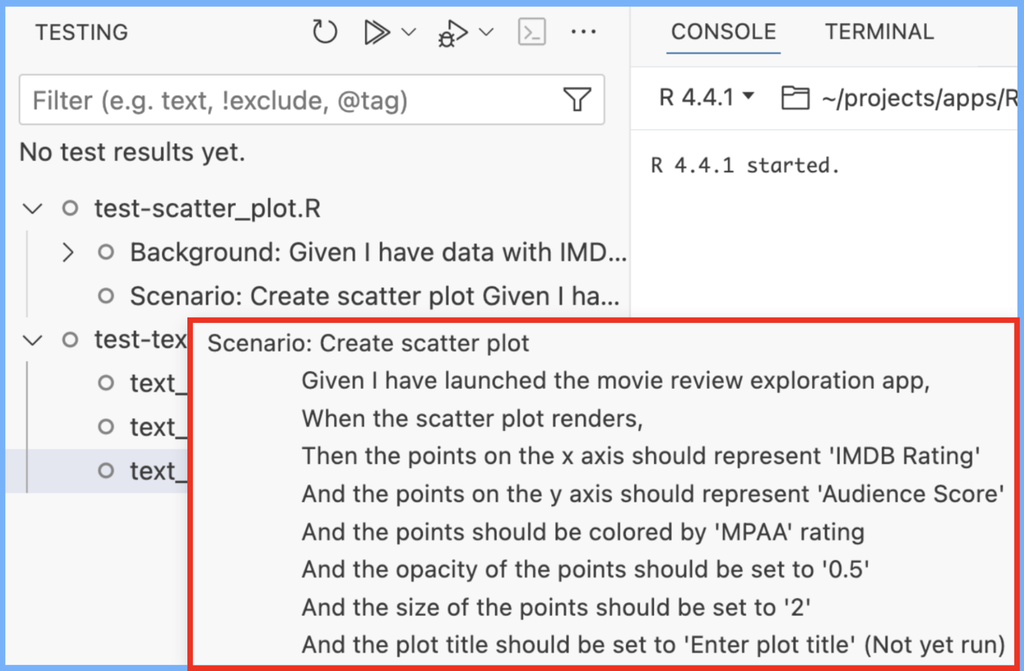

BDD test descriptions (click to enlarge)

If `test_that()` is used, the function being tested is displayed each time an `expect_*` function is called:

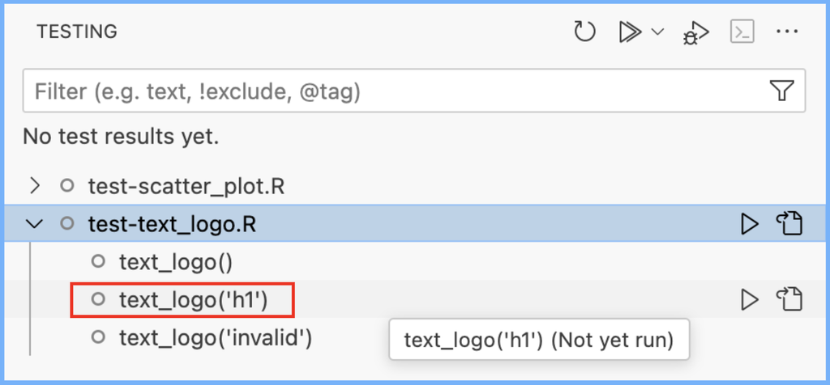

`test_that()` test descriptions (click to enlarge)

### Running tests

The icon under the TESTING sidebar menu item can also be used to run all the tests in the `testthat` folder.

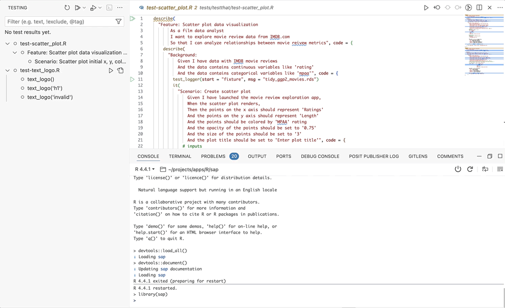

Running tests with icon (click to enlarge)

**TipPackage Development Keyboard Shortcuts**

Two additional shortcuts I recommend adding are:  
`Cmd` / `Ctrl` + `T` = `devtools::test_active_file()`  
`Cmd` / `Ctrl` + `Shift` + `R` = `devtools::test_coverage_active_file()`

Check out Andrew Heiss’ [Positron post](https://www.andrewheiss.com/blog/2024/07/08/fun-with-positron/) for more information on changing keyboard shortcuts

## Recap

Positron brings a refined experience for RStudio users, blending powerful tools in a streamlined layout that promotes an efficient workflow. Here’s a recap of the features we’ve explored:

- **IDE Layout**: Positron’s design ensures smooth navigation. It focuses on customizable panels that allow developers to arrange code editors, data viewers, and debugging consoles based on their workflow.
- **Support for R & Python**: The IDE accommodates multiple versions of R and Python, offering a consistent environment for both languages. Integrated version control helps manage and switch between environments seamlessly, making it ideal for teams working on cross-language projects.
- **Shiny App Development**: Positron provides robust tools for developers to build, test, and deploy Shiny applications. The IDE simplifies UI-building with live previews and reactive programming support, enabling users to refine interactive components.
- **Package Development**: Positron includes a comprehensive suite for R package development, with features that streamline code documentation, testing, and version management. These tools make it easier to follow best practices, ensuring well-organized, maintainable packages.

Positron can enhance productivity for R and Python users, making it a strong choice for data science and development.

## Footnotes

[^1]: I’m using version 2024.07.0-107
[^2]: The **Variables** pane is similar to the **Environments** pane in RStudio.
[^3]: These packages are described in the [R prerequisites section](https://positron.posit.co/start.html#r-prerequisites).
[^4]: [`sap`](https://github.com/mjfrigaard/sap) is the Shiny app-package I used to demonstrate development in my [Shiny-App-Packages](https://mjfrigaard.github.io/shiny-app-pkgs/) book.
[^5]: I’m using a branch from [`sap`](https://github.com/mjfrigaard/sap/), which is a collection of Shiny apps/R packages.
[^6]: Read more on [Garrick’s blog](https://www.garrickadenbuie.com/)
[^7]: The Open VXS Registry is manages by the [Eclipse Foundation](https://www.eclipse.org/).
[^8]: Read more on [Andrew’s blog](https://www.andrewheiss.com/blog/)
[^9]: Read more on [Veerle’s blog](https://hypebright.nl/index.php/home/blog/)
[^10]: I’m demoing the [`02.1_shiny-app`](https://github.com/mjfrigaard/moviesApp/tree/02.1_shiny-app), which is a boilerplate Shiny app project with the Old Faithful Geyser data.
[^11]: Read more about Shiny development mode [here.](https://shiny.posit.co/r/reference/shiny/latest/devmode.html)
[^12]: This is covered in the [`08_launch-app`](https://github.com/mjfrigaard/sap/tree/08_launch-app) branch of `moviesApp`, which is covered in the [Launch](https://mjfrigaard.github.io/shiny-app-pkgs/launch.html) chapter of Shiny-App-Packages.
[^13]: I’m demonstrating with the [`12.3_tests-snapshots`](https://github.com/mjfrigaard/sap/tree/12.3_tests-snapshots) branch of `sap`, which is covered in the [Test Tools](https://mjfrigaard.github.io/shiny-app-pkgs/test_tools.html) chapter of Shiny-App-Packages.

[interactive chart not shown]